# Lab 5

Becca Reynolds

10/28/2019

## Objectives:

- Getting counts for different groups
- Use {lubridate} to parse dates
- Find confidence intervals & do t-tests with t.test()
- Heatmap with geom_tile()

```r
# Import Lobster Data

lobster_abundance <-
  read_csv(here::here("data", "lobster_abundance.csv"),
                              na = "-99999") %>%
  clean_names()
```

```r
lobster_tidy <- lobster_abundance %>%
  tidyr::uncount(lobster_count)
```

Now each lobster has its own row. This is tidy format.

Let’s look at this data a bunch of ways…aka exploratory data visualization

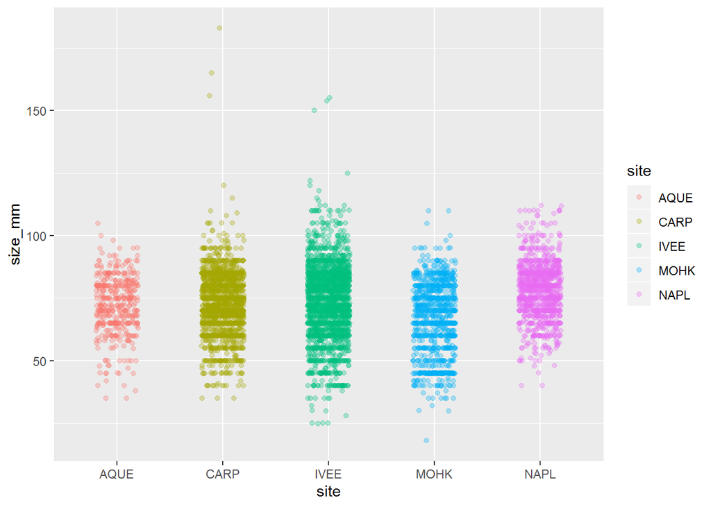

```r
ggplot(data = lobster_tidy, aes(x = site, y = size_mm)) +
  geom_jitter(aes(color = site),
              width = 0.2,
              alpha = 0.3)
```

Some of these have close to the same central tendency, CARP and IVEE have more outliers…

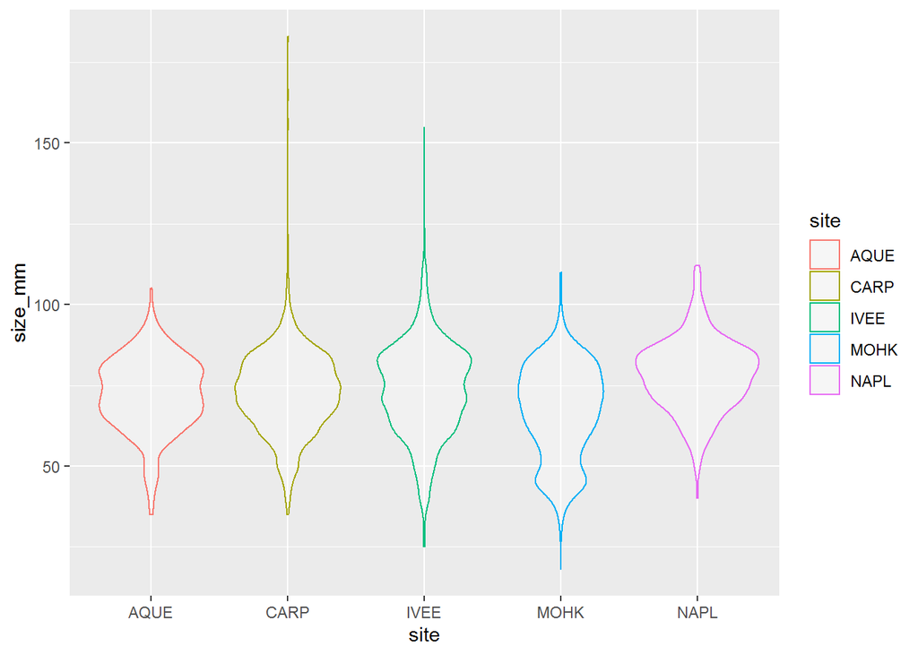

```r
ggplot(data = lobster_tidy, aes(x = site, y = size_mm)) +
  geom_violin(aes(color = site),
              alpha = 0.3)
```